# Final Lab

Скубников Кирилл, Титов Алексей, Назаров Антон

```r
library(ROCR)
```

## Загрузка подготовленного датасета

## Статистика отношения заполненных/незаполненных данных, полученная в процессе чистки на Python (Notebook приложен)

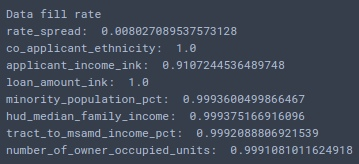

## Определение факторов датафрейма

```r
dataset$loan_type = factor(dataset$loan_type)
dataset$loan_purpose = factor(dataset$loan_purpose)
dataset$preapproval = factor(dataset$preapproval)
dataset$action_type = factor(dataset$action_type)
dataset$county_name=factor(dataset$county_name)
dataset$lien_status = factor(dataset$lien_status)
dataset$applicant_ethnicity = factor(dataset$applicant_ethnicity)
dataset$applicant_race_1 = factor(dataset$applicant_race_1)
dataset$applicant_sex = factor(dataset$applicant_sex)
dataset$state_name = factor(dataset$state_name)
```

## Исследование исходных данных

### Исследование зависимости спреда ставки от состояния заявки

Ипотечные заявки без указанного спреда ставки являются единственным видом заявок, прошедшие рассмотрение и по которым вынесен вердикт отличный от выдачи кредита. Кредиты со спредом, отличным от 0, находятся в исключительно “выданном” состоянии.

```r
with(dataset, head(table(rate_spread, action_type), n = 15))
```

[output not shown]

### Исследование зависимости отношения статуса предварительного одобрения и расы

Отношение Запрошенных/отклоненных заявок:

| Раса | Запрошенных/отклоненных заявок |
| --- | --- |
| AmerInd.AlaskaNat | 0,025510204 |
| Asian | 0,031478915 |
| Black.AfroAmer | 0,041154995 |
| Hawaiian.PacificIs | 0,037037037 |
| No Info | 0,01891855 |
| Not Applicable | 0,012048193 |
| White | 0,028921694 |

Афроамериканцы реже получают предварительный отказ чем другие расы

```r
with(dataset, table(applicant_race_1, preapproval))
```

```
                    preapproval
applicant_race_1     Not applicable Not requested Requested
  AmerInd.AlaskaNat            1372           287        35
  Asian                        5051           958       159
  Black.AfroAmer               3013           867       124
  Hawaiian.PacificIs            567           116        21
  No Info                     21989          2962       416
  Not Applicable                 83             4         1
  White                      132634         23801      3836
```

Предположим, что средний доход является значимым фактором:

```r
tract_median_income <- with(dataset, hud_median_family_income*(tract_to_msamd_income_pct/100))
dataset$tract_median_income_ink <- round(tract_median_income/1000)
```

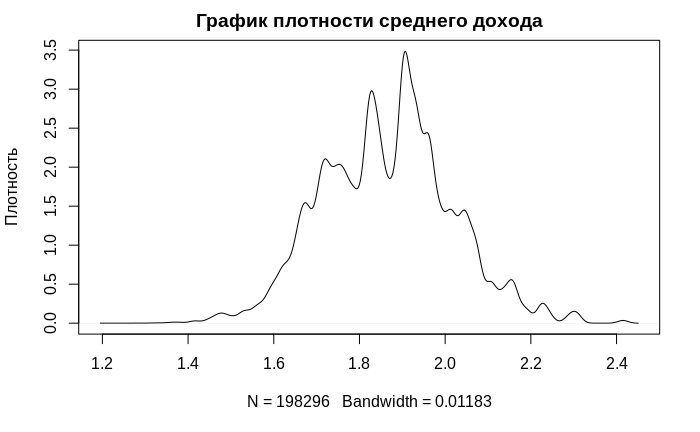

```r
den = density(log10(dataset$tract_median_income_ink))
plot(den, main = "График плотности среднего дохода", ylab = "Плотность")
```

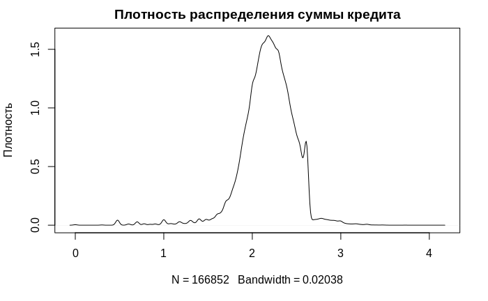

```r
plot(density(log10(dataset$loan_amount_ink)), main = "Плотность распределения суммы кредита", ylab = "Плотность")
```

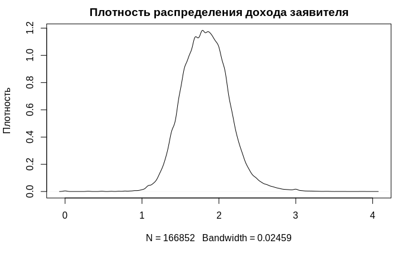

```r
plot(density(log10(dataset$applicant_income_ink)), main = "Плотность распределения дохода заявителя", ylab = "Плотность")
```

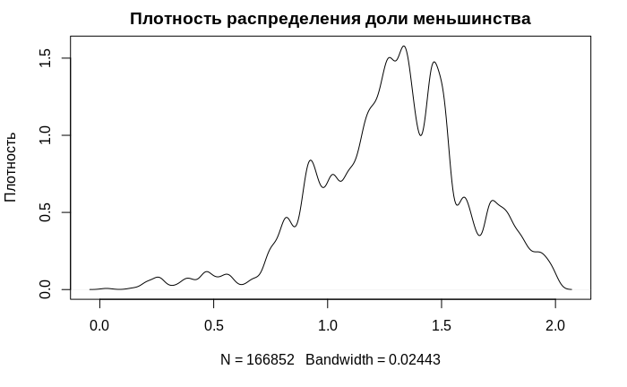

```r
plot(density(log10(dataset$minority_population_pct)), main = "Плотность распределения доли меньшинства", ylab = "Плотность")
```

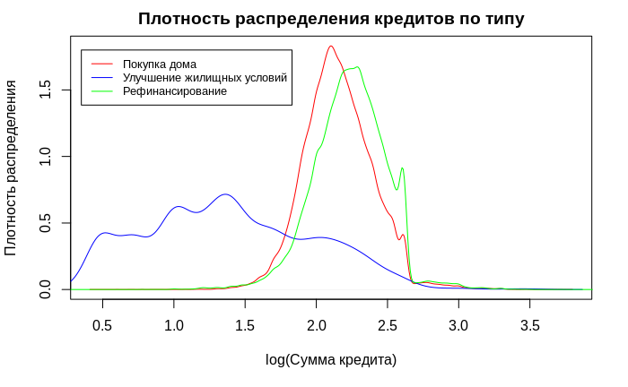

```r
with(dataset,  {
 homepurchase <- density(log10(subset(loan_amount_ink, loan_purpose=="Home purchase")))
 homeimprovement <- density(log10(subset(loan_amount_ink, loan_purpose=="Home improvement")))
 refinance <- density(log10(subset(loan_amount_ink, loan_purpose=="Refinancing")))

 plot(homepurchase, col="red", main="Плотность распределения кредитов по типу" , xlab = "log(Сумма кредита)", ylab = "Плотность распределения")
 lines(homeimprovement, col="blue")
 lines(refinance, col="green")
 legend(0.35, 1.8, legend=c("Покупка дома", "Улучшение жилищных условий", "Рефинансирование"),
       col=c("red", "blue", "green"), lty=1, cex=0.8)
})
```

Нас интересуют действия по выдаче кредита либо отказу. Отфильтруем данные и создадим дополнительный столбец:

```r
filter <- with(dataset, action_type %in% c("Originated", "Denied"))
dataset <- dataset[filter,]
dataset$approved <- dataset$action_type =="Originated"
```

Первоначальные вероятности одобрения кредита:

```r
table(dataset$approved)/dim(dataset)[1]
```

```
    FALSE      TRUE
0.2253794 0.7746206
```

## Построение модели

Нашей зависимой переменной является одобрение кредита:

```r
depended <- "approved"
```

Также перечислим влияющие переменные (для денежных переменных используется log):

```r
predictors = c("log10(tract_median_income_ink)",  "log10(applicant_income_ink)", "log10(loan_amount_ink)", "loan_type", "loan_purpose", "lien_status", "applicant_race_1", "applicant_ethnicity", "applicant_sex", "county_name", "minority_population_pct")
```

В целях удобства построим строковое представление регресионной зависимости для дальнейшего ее использования в процессе построения модели. (подход найден на просторах всемирной сети :))

```r
modelStringRepresentation = paste(depended, "~", paste(predictors, collapse=" + "))
modelStringRepresentation
```

```
[1] "approved ~ log10(tract_median_income_ink) + log10(applicant_income_ink) + log10(loan_amount_ink) + loan_type + loan_purpose + lien_status + applicant_race_1 + applicant_ethnicity + applicant_sex + county_name + minority_population_pct"
```

```r
dataset$gp <- runif(dim(dataset)[1])
smallset <- subset(dataset, dataset$gp < 0.15) # 15% of data
smallset$X <- NULL
```

```r
firstModel <- glm(modelStringRepresentation, data = smallset, family = binomial(link = "logit"))
summary(firstModel)
```

```
Call:
glm(formula = modelStringRepresentation, family = binomial(link = "logit"),
    data = smallset)

Deviance Residuals:
    Min       1Q   Median       3Q      Max
-2.6591   0.3998   0.5845   0.7379   2.4843

Coefficients:
                                         Estimate Std. Error z value             Pr(>|z|)
(Intercept)                             -3.078302   0.396121  -7.771  0.00000000000000778 ***
log10(tract_median_income_ink)           1.503626   0.173892   8.647 < 0.0000000000000002 ***
log10(applicant_income_ink)              0.999098   0.072467  13.787 < 0.0000000000000002 ***
log10(loan_amount_ink)                  -1.145826   0.088238 -12.986 < 0.0000000000000002 ***
loan_typeFHA                            -0.104769   0.046622  -2.247              0.02463 *
loan_typeFSA.RHS                        -0.022658   0.140435  -0.161              0.87182
loan_typeVA                             -0.041914   0.085115  -0.492              0.62241
loan_purposeHome purchase                2.128488   0.132932  16.012 < 0.0000000000000002 ***
loan_purposeRefinancing                  1.110393   0.129444   8.578 < 0.0000000000000002 ***
lien_statusNo lien                      -1.808806   0.216559  -8.352 < 0.0000000000000002 ***
lien_statusSubordinate lien             -1.635533   0.149099 -10.969 < 0.0000000000000002 ***
applicant_race_1Asian                    0.520828   0.188845   2.758              0.00582 **
applicant_race_1Black.AfroAmer           0.376092   0.197524   1.904              0.05691 .
applicant_race_1Hawaiian.PacificIs       0.852129   0.382659   2.227              0.02596 *
applicant_race_1No Info                  0.518591   0.188121   2.757              0.00584 **
applicant_race_1Not Applicable          25.627985 340.135536   0.075              0.93994
applicant_race_1White                    0.761061   0.167013   4.557  0.00000519137092009 ***
applicant_ethnicityNo Info               0.067769   0.103166   0.657              0.51125
applicant_ethnicityNon Hispanic.Latino   0.295657   0.054428   5.432  0.00000005569584566 ***
applicant_ethnicityNot Applicable       11.468592 324.743726   0.035              0.97183
applicant_sexMale                        0.076505   0.037859   2.021              0.04330 *
applicant_sexNo Info                     0.046122   0.091842   0.502              0.61554
applicant_sexNot Applicable            -24.686139 459.256970  -0.054              0.95713
county_nameGila                         -0.301206   0.219505  -1.372              0.17000
county_nameGraham                       -0.445117   0.251267  -1.771              0.07648 .
county_nameGreenlee                     -1.770440   0.876834  -2.019              0.04347 *
county_nameLa Paz                       -0.758325   0.411688  -1.842              0.06548 .
county_nameMaricopa                     -0.127340   0.115854  -1.099              0.27170
county_nameMohave                       -0.400879   0.150284  -2.667              0.00764 **
county_namePima                          0.194612   0.119590   1.627              0.10367
county_namePinal                        -0.185044   0.132860  -1.393              0.16369
county_nameYavapai                      -0.066460   0.142031  -0.468              0.63984
county_nameYuma                          0.361075   0.159434   2.265              0.02353 *
minority_population_pct                 -0.005392   0.001270  -4.245  0.00002186254320407 ***
---
Signif. codes:  0 ‘***’ 0.001 ‘**’ 0.01 ‘*’ 0.05 ‘.’ 0.1 ‘ ’ 1

(Dispersion parameter for binomial family taken to be 1)

    Null deviance: 24822  on 22955  degrees of freedom
Residual deviance: 22941  on 22922  degrees of freedom
AIC: 23009

Number of Fisher Scoring iterations: 11
```

```r
1 - firstModel$deviance/firstModel$null.deviance
```

```
[1] 0.06791163
```

```r
predictorsSecond = c("log10(tract_median_income_ink)",  "log10(applicant_income_ink)", "log10(loan_amount_ink)", "loan_type", "loan_purpose", "lien_status", "county_name", "minority_population_pct")
```

```r
modelString = paste(depended, "~", paste(predictorsSecond, collapse=" + "))
modelString
```

```
[1] "approved ~ log10(tract_median_income_ink) + log10(applicant_income_ink) + log10(loan_amount_ink) + loan_type + loan_purpose + lien_status + county_name + minority_population_pct"
```

```r
secondModel <- glm(modelString, data = smallset, family = binomial(link = "logit"))
summary(secondModel)
```

```
Call:
glm(formula = modelString, family = binomial(link = "logit"),
    data = smallset)

Deviance Residuals:
    Min       1Q   Median       3Q      Max
-2.6265   0.4114   0.5924   0.7411   2.4881

Coefficients:
                                Estimate Std. Error z value             Pr(>|z|)
(Intercept)                    -1.955402   0.355277  -5.504      0.0000000371511 ***
log10(tract_median_income_ink)  1.420954   0.172775   8.224 < 0.0000000000000002 ***
log10(applicant_income_ink)     1.043104   0.071595  14.569 < 0.0000000000000002 ***
log10(loan_amount_ink)         -1.141675   0.087782 -13.006 < 0.0000000000000002 ***
loan_typeFHA                   -0.119456   0.046181  -2.587              0.00969 **
loan_typeFSA.RHS               -0.027106   0.139862  -0.194              0.84633
loan_typeVA                    -0.028934   0.084058  -0.344              0.73068
loan_purposeHome purchase       2.122462   0.132161  16.060 < 0.0000000000000002 ***
loan_purposeRefinancing         1.104353   0.128728   8.579 < 0.0000000000000002 ***
lien_statusNo lien             -1.883667   0.215096  -8.757 < 0.0000000000000002 ***
lien_statusSubordinate lien    -1.647413   0.148287 -11.110 < 0.0000000000000002 ***
county_nameGila                -0.295880   0.218578  -1.354              0.17585
county_nameGraham              -0.419140   0.249794  -1.678              0.09336 .
county_nameGreenlee            -1.726978   0.868238  -1.989              0.04669 *
county_nameLa Paz              -0.741222   0.409214  -1.811              0.07009 .
county_nameMaricopa            -0.126595   0.115116  -1.100              0.27145
county_nameMohave              -0.403081   0.149590  -2.695              0.00705 **
county_namePima                 0.195031   0.118873   1.641              0.10087
county_namePinal               -0.160646   0.132007  -1.217              0.22363
county_nameYavapai             -0.065506   0.141216  -0.464              0.64274
county_nameYuma                 0.352333   0.158277   2.226              0.02601 *
minority_population_pct        -0.007857   0.001214  -6.470      0.0000000000981 ***
---
Signif. codes:  0 ‘***’ 0.001 ‘**’ 0.01 ‘*’ 0.05 ‘.’ 0.1 ‘ ’ 1

(Dispersion parameter for binomial family taken to be 1)

    Null deviance: 24822  on 22955  degrees of freedom
Residual deviance: 23087  on 22934  degrees of freedom
AIC: 23131

Number of Fisher Scoring iterations: 4
```

```r
1 - secondModel$deviance/secondModel$null.deviance
```

```
[1] 0.06153939
```

Результаты без использования личных данных немного хуже полной модели. Лучше исходные данные объясняет полная модель. Попробуем построить модель на большей выборке

Выберем 25% от исходных данных (использован код из подсказки)

```r
dataset$gp <- runif(dim(dataset)[1])
smallset2 <- subset(dataset, dataset$gp < 0.25) # 15% of data
smallset2$X <- NULL
```

```r
thirdModel <- glm(modelStringRepresentation, data = smallset2, family = binomial(link = "logit"))
summary(thirdModel)
```

```
Call:
glm(formula = modelStringRepresentation, family = binomial(link = "logit"),
    data = smallset2)

Deviance Residuals:
    Min       1Q   Median       3Q      Max
-2.5658   0.4143   0.5842   0.7305   2.3697

Coefficients:
                                         Estimate Std. Error z value Pr(>|z|)
(Intercept)                            -2.451e+00  3.113e-01  -7.874 3.44e-15 ***
log10(tract_median_income_ink)          1.311e+00  1.380e-01   9.500  < 2e-16 ***
log10(applicant_income_ink)             8.507e-01  5.746e-02  14.805  < 2e-16 ***
log10(loan_amount_ink)                 -9.820e-01  6.878e-02 -14.277  < 2e-16 ***
loan_typeFHA                           -1.032e-01  3.656e-02  -2.823 0.004759 **
loan_typeFSA.RHS                        1.002e-01  1.173e-01   0.854 0.392991
loan_typeVA                            -1.319e-01  6.586e-02  -2.003 0.045127 *
loan_purposeHome purchase               2.027e+00  9.725e-02  20.842  < 2e-16 ***
loan_purposeRefinancing                 1.030e+00  9.421e-02  10.937  < 2e-16 ***
lien_statusNo lien                     -1.534e+00  1.674e-01  -9.165  < 2e-16 ***
lien_statusSubordinate lien            -1.800e+00  1.150e-01 -15.649  < 2e-16 ***
applicant_race_1Asian                   2.957e-01  1.534e-01   1.927 0.053948 .
applicant_race_1Black.AfroAmer          8.398e-02  1.601e-01   0.524 0.600017
applicant_race_1Hawaiian.PacificIs      3.535e-01  2.493e-01   1.418 0.156145
applicant_race_1No Info                 2.535e-01  1.517e-01   1.671 0.094668 .
applicant_race_1Not Applicable          3.867e-01  1.837e+02   0.002 0.998320
applicant_race_1White                   5.128e-01  1.358e-01   3.777 0.000159 ***
applicant_ethnicityNo Info              1.531e-01  8.102e-02   1.889 0.058858 .
applicant_ethnicityNon Hispanic.Latino  3.291e-01  4.225e-02   7.790 6.71e-15 ***
applicant_ethnicityNot Applicable      -1.153e+01  1.834e+02  -0.063 0.949854
applicant_sexMale                       4.302e-02  2.973e-02   1.447 0.147909
applicant_sexNo Info                   -1.298e-01  7.158e-02  -1.814 0.069714 .
applicant_sexNot Applicable             2.339e+01  2.444e+02   0.096 0.923749
county_nameGila                        -2.932e-01  1.732e-01  -1.693 0.090388 .
county_nameGraham                      -2.135e-01  2.051e-01  -1.041 0.297837
county_nameGreenlee                    -1.100e+00  6.235e-01  -1.765 0.077617 .
county_nameLa Paz                      -4.752e-01  3.963e-01  -1.199 0.230543
county_nameMaricopa                    -8.061e-02  9.350e-02  -0.862 0.388635
county_nameMohave                      -3.013e-01  1.203e-01  -2.505 0.012248 *
county_namePima                         1.797e-01  9.630e-02   1.866 0.062097 .
county_namePinal                       -1.565e-01  1.071e-01  -1.462 0.143819
county_nameYavapai                     -2.549e-01  1.123e-01  -2.270 0.023227 *
county_nameYuma                         4.803e-01  1.278e-01   3.758 0.000171 ***
minority_population_pct                -6.559e-03  9.985e-04  -6.568 5.09e-11 ***
---
Signif. codes:  0 ‘***’ 0.001 ‘**’ 0.01 ‘*’ 0.05 ‘.’ 0.1 ‘ ’ 1

(Dispersion parameter for binomial family taken to be 1)

    Null deviance: 40516  on 37909  degrees of freedom
Residual deviance: 37584  on 37876  degrees of freedom
AIC: 37652

Number of Fisher Scoring iterations: 11
```

```r
1 - thirdModel$deviance/thirdModel$null.deviance
```

```
[1] 0.07236375
```

С увеличением выборки и применением исходной модели независимых переменных позволило получить лучший результат

```r
thirdModelPrediction <- prediction(predict(firstModel, type = "response"), smallset$approved)
rocThirdModel <- performance(thirdModelPrediction, "tpr", x.measure = "fpr")
aucThirdModel <- performance(thirdModelPrediction, "auc")
```

```r
secondModelPrediction <- prediction(predict(secondModel, type = "response"), smallset$approved)
rocSecondModel <- performance(secondModelPrediction, "tpr", x.measure = "fpr")
aucSecondModel <- performance(secondModelPrediction, "auc")
```

```r
print(aucThirdModel@y.values[1])
```

```
[[1]]
[1] 0.6743455
```

```r
print(aucSecondModel@y.values[1])
```

```
[[1]]
[1] 0.6672057
```

```r
#plot(rocThirdModel@x.values[[1]], rocThirdModel@x.values[[1]], type="l", col='gray', xlab="fpr", ylab="tpr",  )
plot(rocThirdModel, col="red", main="ROC")
plot(rocSecondModel, text.col="blue", col="blue", add=T)
```

[figure not shown]

```r
legend(0.01, 1, legend=c("Модель с личными данными", "Модель без личных данных"),
       col=c("red", "blue"), lty=1, cex=0.8)
```

```r
low = 0.5
high = 0.75
```

Тестовая выборка 35%

```r
dataset$gp <- runif(dim(dataset)[1])
test <- subset(dataset, dataset$gp < 0.35)
test$X <- NULL
```

```r
testPrediciton <- predict(thirdModel, newdata = test, type = "response")
```

Замена числовых значений формализованным текстовым представлением

```r
formalisedResult <- cut(testPrediciton, breaks = c(0, low, high, 1.0), labels = c("low", "middle", "hi"), include.lowest=T)
```

Отношение числа заявок к сумме кол-ва формализованных результатов

```r
options(scipen=999)
colSums(resultTable)/sum(colSums(resultTable))
```

```
       low     middle         hi
0.03471449 0.29579991 0.66948561
```